# Quantitative Methods for HIV Researchers

Graphics with ggplot2

Janice M. McCarthy

June 9, 2022

# R Graphics

```r
library(tidyverse)
```

```r
options.orig <- options(repr.plot.width=6, repr.plot.height=4)
```

## Simulate some data for plotting

```r
n <- 100
x <- sort(runif(n))
y <- x^2 + x + 3 + 0.2*rnorm(n)
z <- x^2
g <- as.factor(sample(1:4, n, replace=T))
df <- tibble(x=x, y=y, z=z, g=g)

df
```

```
## # A tibble: 100 × 4
##          x     y         z g
##      <dbl> <dbl>     <dbl> <fct>
##  1 0.00794  2.91 0.0000630 3
##  2 0.0223   3.00 0.000498  4
##  3 0.0231   2.85 0.000532  4
##  4 0.0508   3.19 0.00258   1
##  5 0.0511   3.11 0.00261   4
##  6 0.0565   2.94 0.00319   4
##  7 0.0567   3.18 0.00322   2
##  8 0.0632   3.07 0.00400   4
##  9 0.0763   3.05 0.00582   3
## 10 0.0787   3.19 0.00619   3
## # … with 90 more rows
```

## Grammar of Graphics

`ggplot2` uses a Grammar of Graphics convention to define plots. See [The fundamentals of `gggplot2` explained](https://www.aridhia.com/technical-tutorials/the-fundamentals-of-ggplot-explained/) for a simple explanation.

The main concents are

- **data source** a data frame or tibble
- **map** data elements to visual characteristics (aes)
- **type of visual elements** in plot (geom)
- **layers** (+)
- **facet** to automatically show “group by” plots
- **scale** to controls how the mapping is made
- **statistics** to add summary data to the plot
- **themes** to define the look and feel of the plot

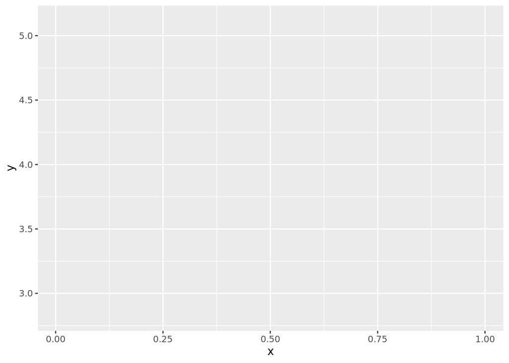

```r
g0 <- ggplot(df, aes(x=x, y=y))

g0
```

Here we see just an empty plot with axes for $x$ and $y$. This is because we have only told `ggplot` what mappings we want to use (i.e. x axis is the ‘x’ column in our data frame and y axis is the ‘y’ column.)

We have to add a `geom` (or a `stat`) in order to see somthing on the plot:

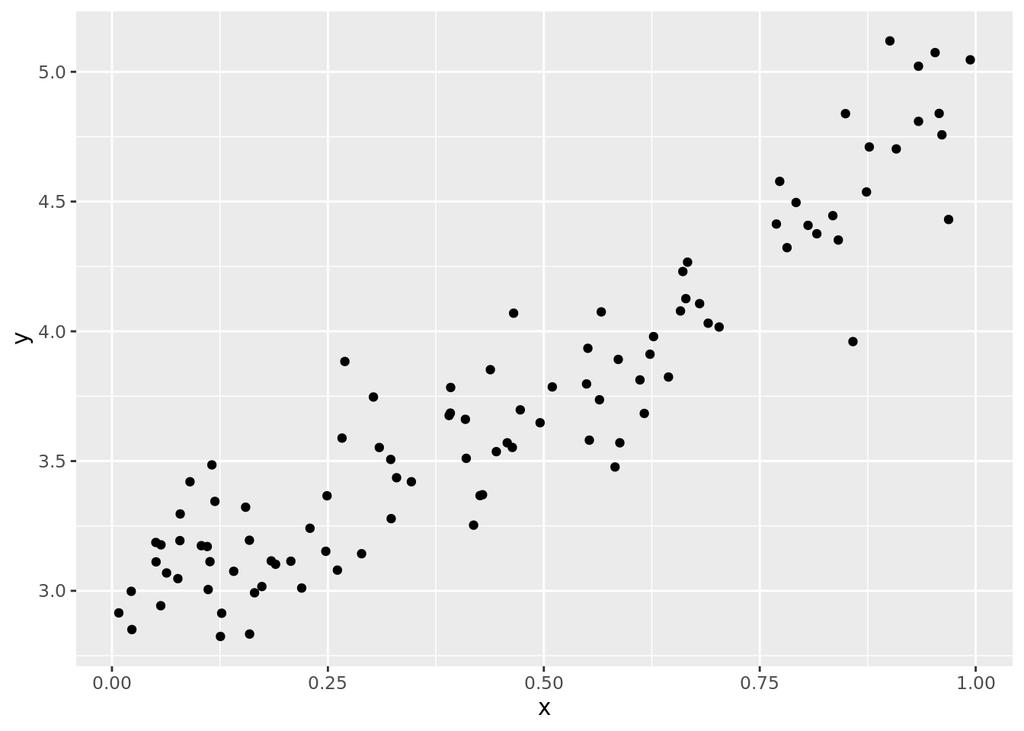

```r
g1 <- g0 +
      geom_point()

g1
```

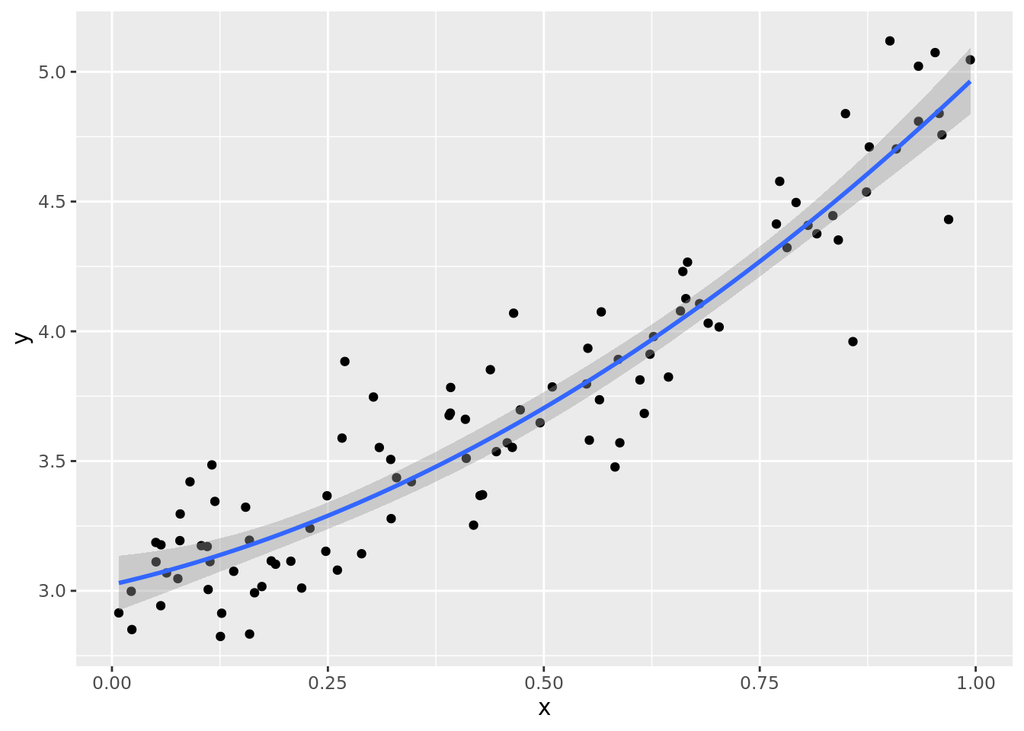

```r
g2 <- g1 +
      geom_smooth(method='lm',
              formula=y ~ poly(x, 2, raw=TRUE)) # this is a polynomial fit (quadratic because it's degree 2)

g2
```

We can add another ‘dimension’ with color:

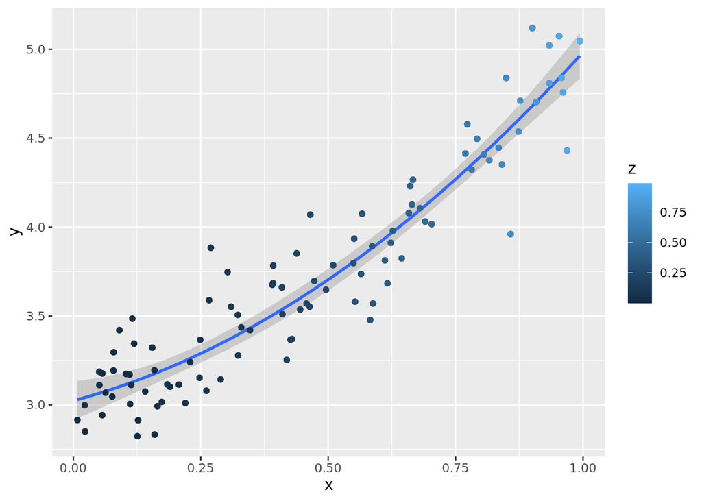

```r
g3 <- g2 +
      geom_point(aes(color = z))

g3
```

We can annote the plot with the `labs` function:

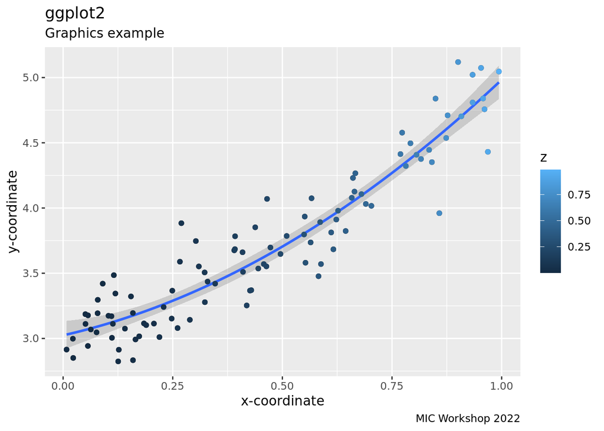

```r
g4 <- g3 +
   labs(title="ggplot2",
        subtitle="Graphics example",
        caption="MIC Workshop 2022",
        x="x-coordinate",
        y="y-coordinate")

g4
```

We can get rid of the color legend using `guides`.

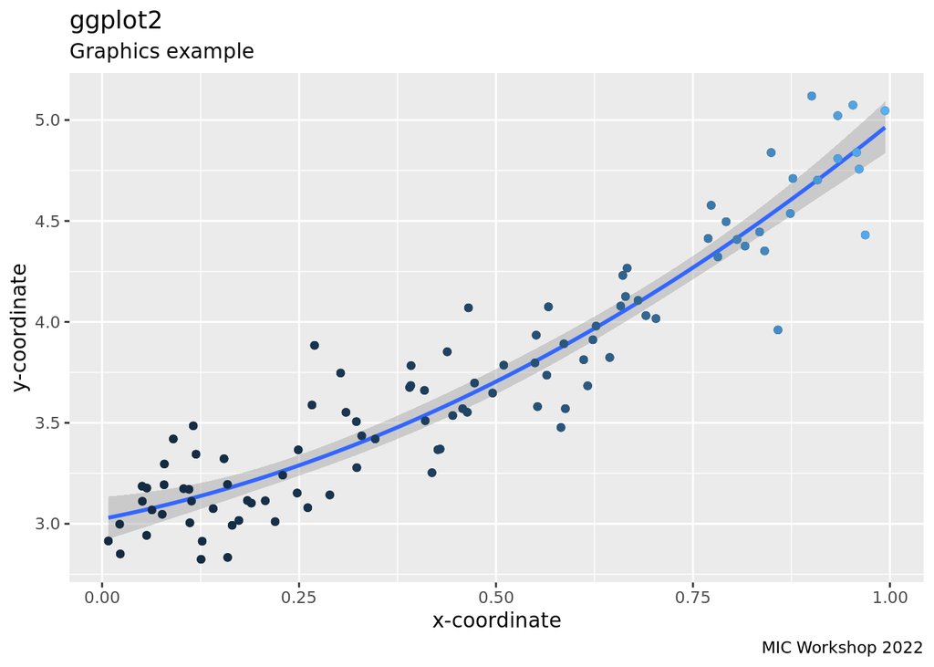

```r
g5 <- g4 +
   guides(col=FALSE)
g5
```

### Themes

Themes are functions that affect the overall look of the plot:

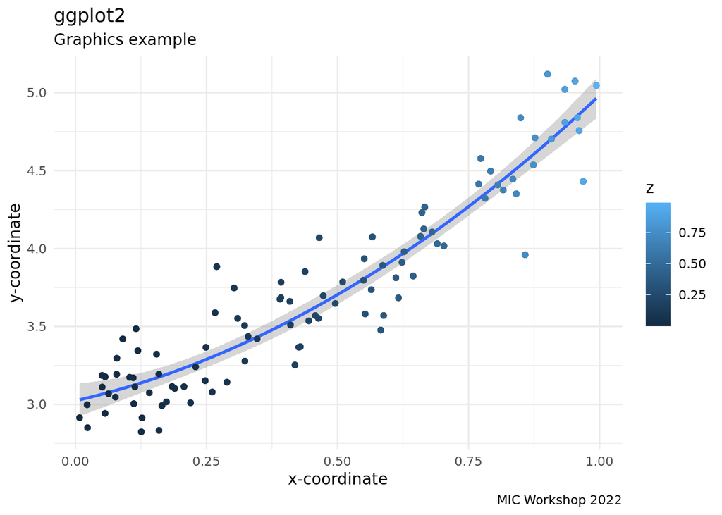

```r
g4 + theme_minimal()
```

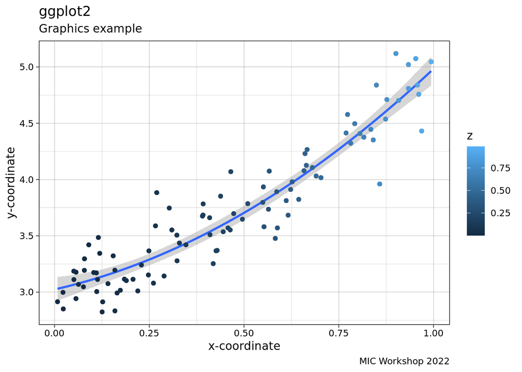

```r
g4 + theme_linedraw()
```

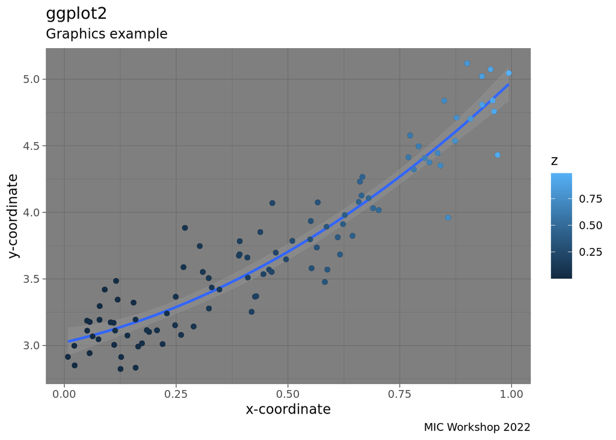

```r
g4 + theme_dark()
```

### Facets

Facets allow for creating parallel plots across categorical varibales:

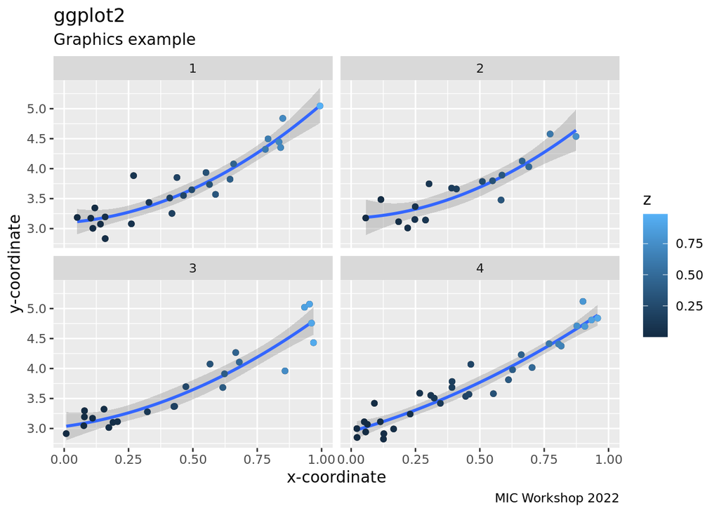

```r
g4 + facet_wrap(facets='g', nrow = 2)
```

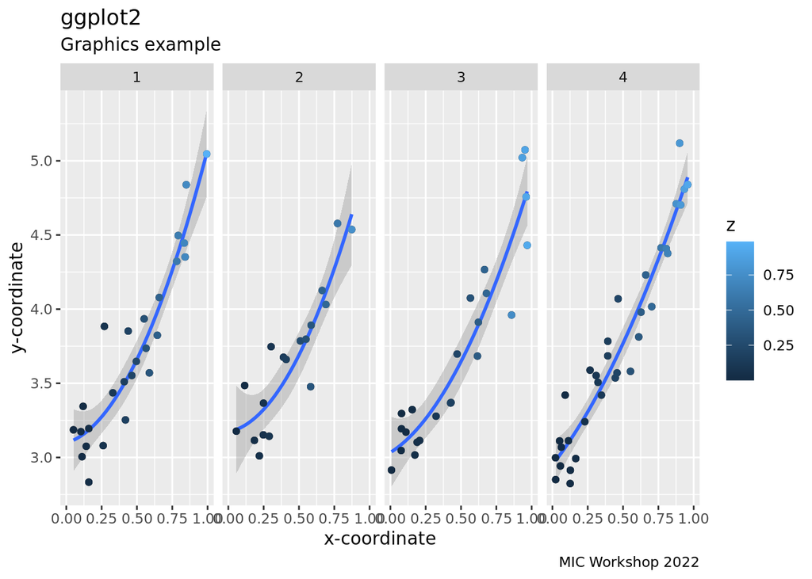

```r
g4 + facet_grid(~ g)
```

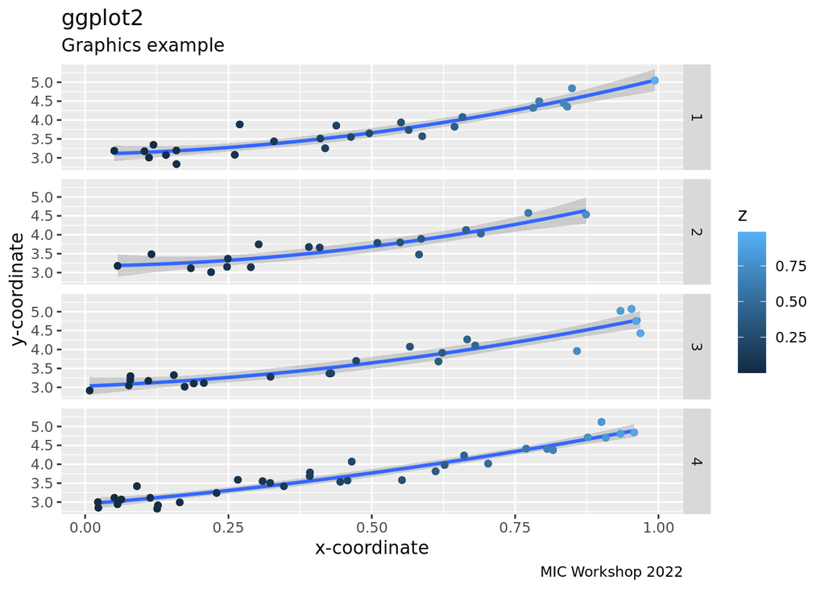

```r
g4 + facet_grid(g ~ .)
```

### Scales

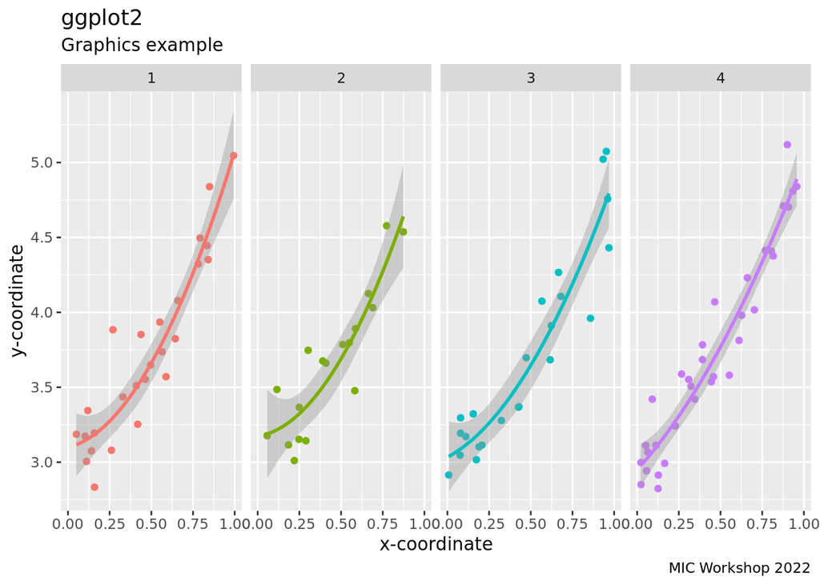

```r
g4 <- ggplot(df, aes(x=x, y=y, col=as.factor(g)) ) +
geom_point() +
geom_smooth(method='lm',
            formula=y ~ poly(x, 2, raw=TRUE)) +
labs(title="ggplot2",
     subtitle="Graphics example",
     caption="MIC Workshop 2022",
     x="x-coordinate",
     y="y-coordinate") +
facet_grid(~ g) +
guides(col=FALSE)
g4
```

#### Colors

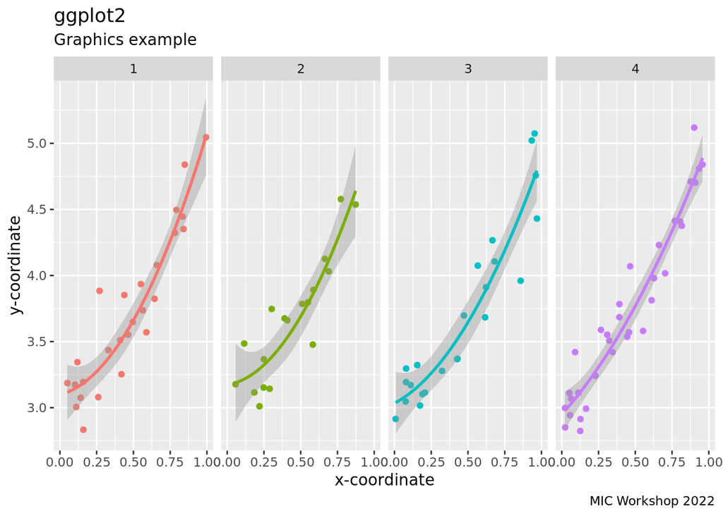

```r
g4
```

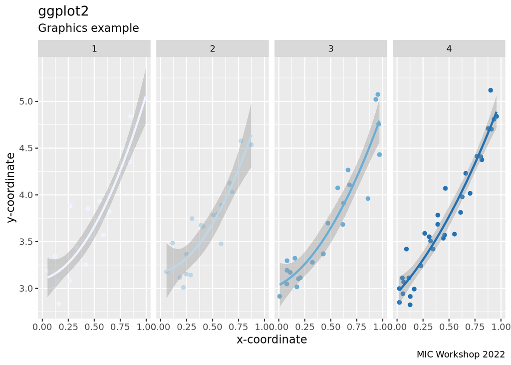

```r
g4 + scale_color_brewer()
```

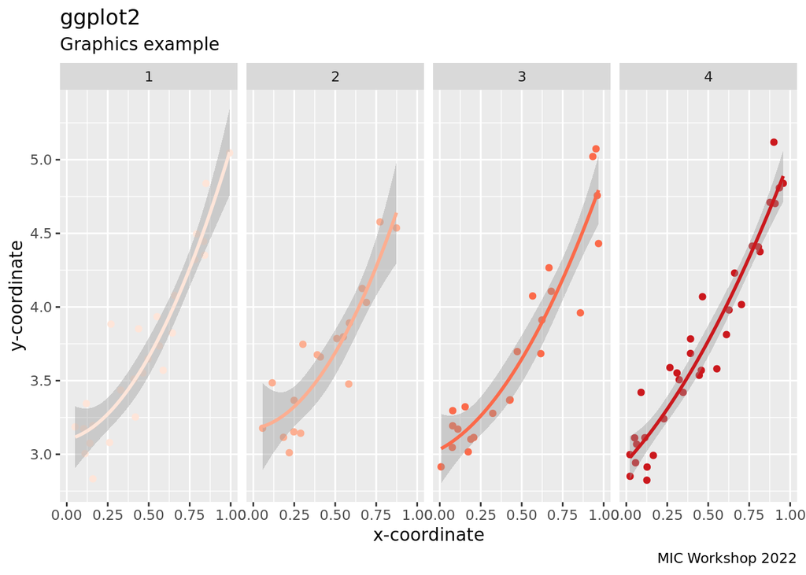

```r
g4 + scale_color_brewer(type = 'seq', palette = 'Reds')
```

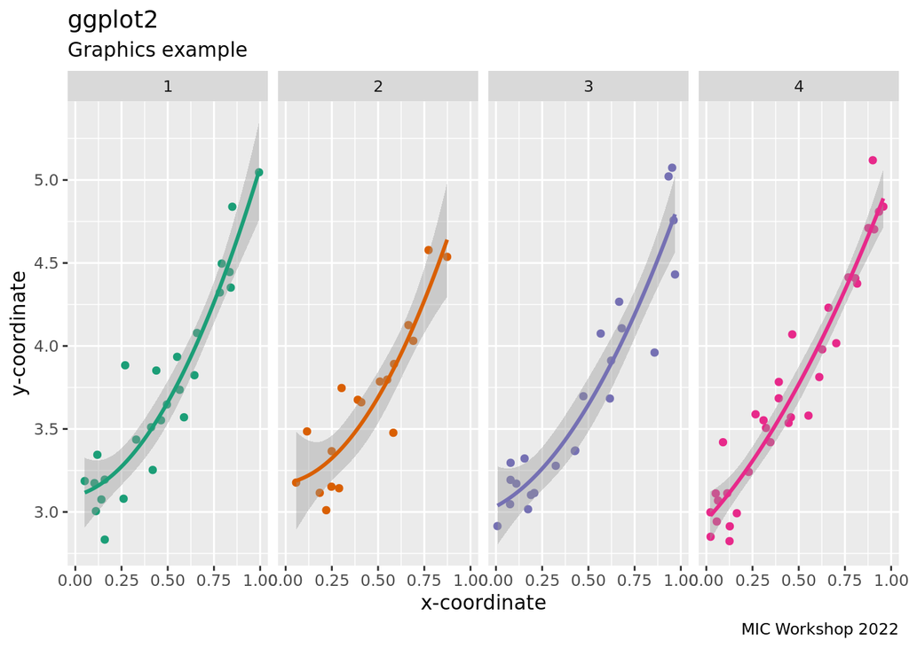

```r
g4 + scale_color_brewer(type = 'qual', palette = 2)
```

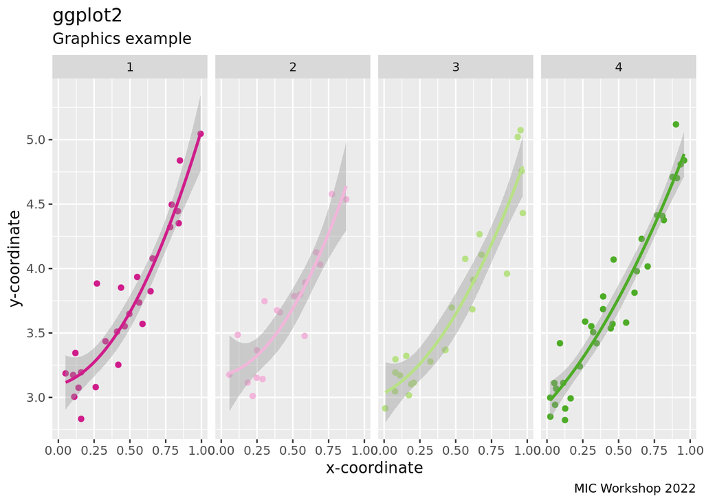

```r
g4 + scale_color_brewer(type = 'div', palette = 2)
```

#### Palettes available from `brewer`

The 3 plots show color maps that are

1. Sequential
2. Qualitiative
3. Divergent

```r
library(RColorBrewer)
```

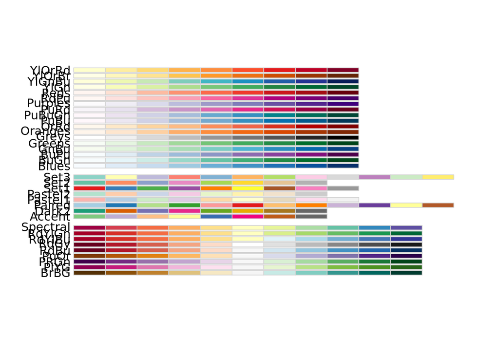

```r
options.orig <- options(repr.plot.width=6, repr.plot.height=12)
display.brewer.all()
```

```r
options.orig <- options(repr.plot.width=6, repr.plot.height=4)
```

#### Scales can be used for changing the mapping of `color`, `fill`, `hue`, `size`, `coordinates` …

Here we scale the y-coordinate to show log values.

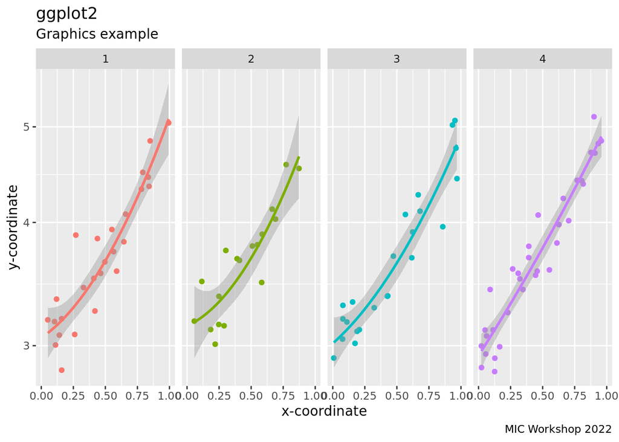

```r
g4 + scale_y_log10()
```

### Geoms

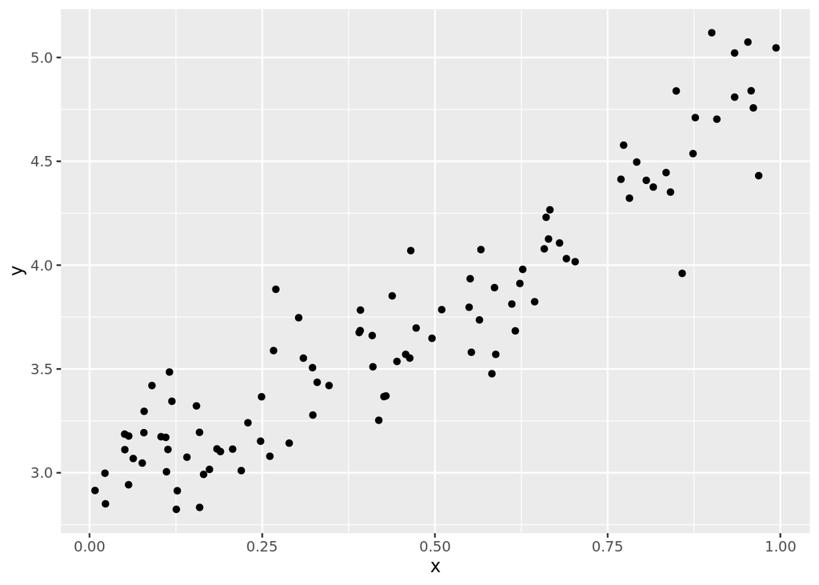

```r
g0 + geom_point()
```

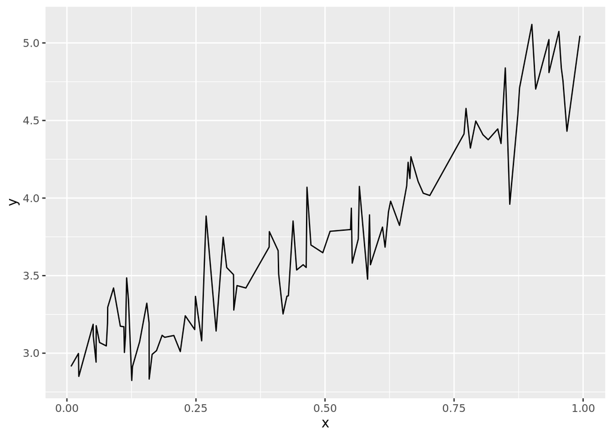

```r
g0 + geom_line()
```

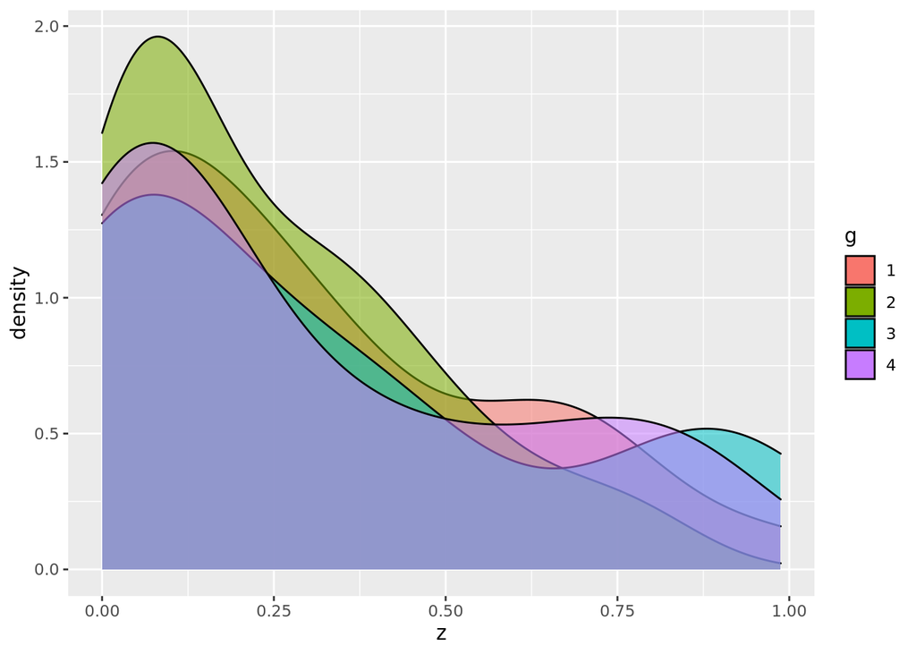

```r
ggplot(df, aes(x=z, fill=g)) +
geom_density(aes(alpha=0.1)) +
guides(alpha=F)
```

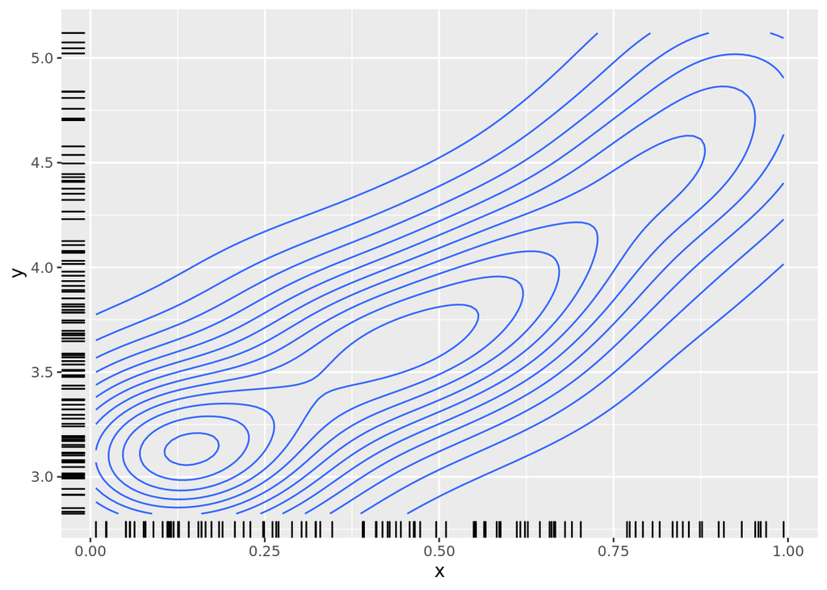

```r
g0 +
geom_density_2d() +
geom_rug()
```

```r
head(df)
```

```
## # A tibble: 6 × 4
##         x     y         z g
##     <dbl> <dbl>     <dbl> <fct>
## 1 0.00794  2.91 0.0000630 3
## 2 0.0223   3.00 0.000498  4
## 3 0.0231   2.85 0.000532  4
## 4 0.0508   3.19 0.00258   1
## 5 0.0511   3.11 0.00261   4
## 6 0.0565   2.94 0.00319   4
```